# Time-To-Event Analysis

## Hall-Wellner simultaneous confidence bands

- Ref: https://www.karlin.mff.cuni.cz/~vavraj/cda/exercise_04.html

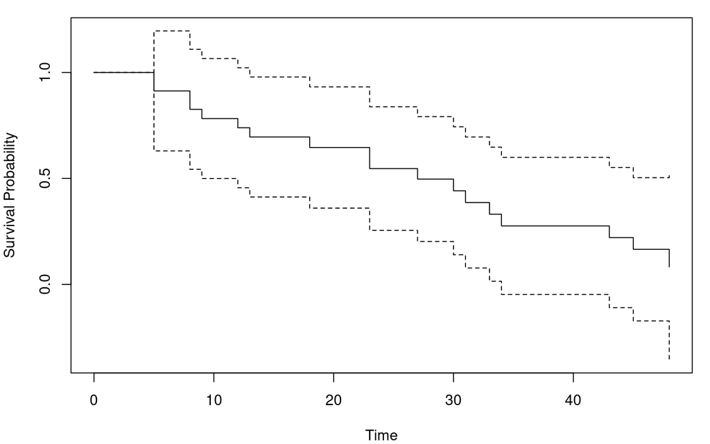

```r
library("km.ci")
fit <- survfit(Surv(time,status)~1, data=aml, conf.type="plain", conf.int=0.95)
out <- km.ci(fit, conf.level=0.95, tl=5, tu=48, method="hall-wellner")
par(mar = c(4,4,1,1))
plot(out, xlab = "Time", ylab = "Survival Probability")
```

# Confidence Band

- Ref: https://www.nature.com/articles/s41416-022-01920-5
- https://scholar.princeton.edu/sites/default/files/mikkelpm/files/conf_band.pdf
- For a one dimensional variable there is a confidence interval, and for a two dimensional plot there is a confidence band.
- Confidence bands is a collections of confidence intervals for each component of a parameter vector.
- Pointwise confidence band: the confidence interval for the survival probability at each time point
  $$\hat{S}(t_i) \pm z_{1 - \alpha/2} \hat{se} (t_i)$$
- Simutaneous confidence band: the probability of $f(x_i)$ is within the intervals for all of $x_i$ . Assuming $n$ times of simulation, less than $\alpha$ percent of $n$ has any of $f(x_i)$ locates outside of the intervals (band).

# Proportional Hazard

## Simulating Data

```r
library(coxed)
library(data.table)
library(survminer)
set.seed(123456)

N = 1000
X <- data.frame(
    fac1 = sample(x = c(0, 1), size = N, replace = TRUE, prob = c(0.6, 0.4))
  , fac2 = rep(c(0, 1), each = N / 2)
  , group = rep(1:(N / 2), 2)
)

surv_obj <- sim.survdata(N = N
                 , T = 500
                 , X = X
                 , hazard.fun = NULL
                 , beta = log(c(2, 2, 1))
                 , censor = .2
                 , num.data.frames = 1
                   )
dt <- surv_obj$data
setDT(dt)
dt$group <- X$group
dt <- dt[, fac1 := factor(fac1, levels = c(0, 1))]
```

## Cox Model

```r
S <- survival::Surv(time = dt$y, event = dt$failed)
m_cox <- coxph(S ~ fac1, data = dt)

tab_model(m_cox)
```

|  | S |  |  |
| --- | --- | --- | --- |
| Predictors | Estimates | CI | p |
| fac1 [1] | 2.18 | 1.87 – 2.53 | **<0.001** |
| Observations | 1000 |  |  |
| R<sup>2</sup> Nagelkerke | 0.092 |  |  |

## Testing proportional Hazards Assumption

- cox.zph() tests corresponding scaled Schoenfeld residuals with time
- The Schoenfeld residuals are the differences between one individual’s covariates values at the event time and the corresponding risk-weighted average of covariate values among all then at risk.
- Schoenfeld’s residuals are defined as
  $$\hat{r}_{(i)} = Z_{(i)} - \frac{\sum Z_j exp(\hat{\beta} Z_j)}{\sum exp(\hat{\beta}Z_j)}$$

where $Z_{i}$ is the covaraite vector at time $i$, and the weight is the risk at the time (hazard) considering all covaraites (each individual has different hazard at the time)

```r
test.ph <- cox.zph(m_cox)
test.ph
```

```
  chisq df    p
```

fac1 0.00285 1 0.96 GLOBAL 0.00285 1 0.96

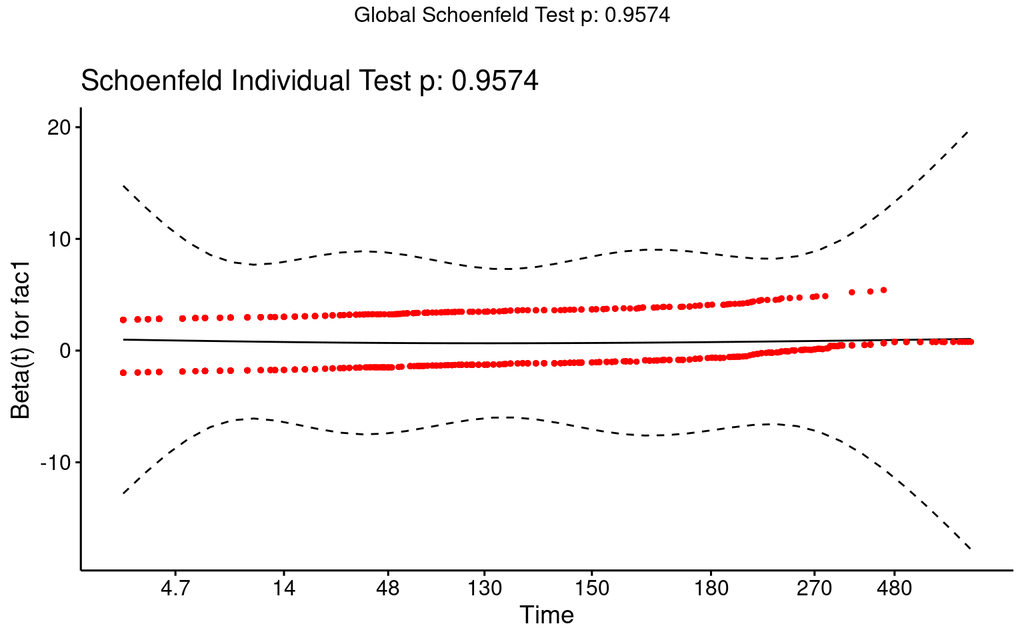

```r
ggcoxzph(test.ph)
```

## Cox Model with mgcv

```r
library(mgcv)

m_gam <- gam(y ~ fac1
           , data = dt
           , family = cox.ph()
           , weights = failed
             )
beta <- m_gam$coefficients
se <- summary(m_gam)$se

exp(c(beta, beta - qnorm(.975) * se, beta + qnorm(0.975) * se))
```

fac11 fac11 fac11 2.165317 1.860764 2.519717

# Sample Size

## Sample size for the proportional hazards model

- Schoenfeld: Sample-Size Formula for the Proportional-Hazards Regression Model
- The total number of events required:
  $$(Z_{\beta} + z_{1 - \alpha})^2/(P_A P_B log_e^2\delta)$$
- $P_A$ is the proportion of the patients randomized to the treatment A group
- $\delta$ is the hazard ratio (A as reference)

```r
alpha = 0.05
beta = 0.8
q1 = 0.66
q0 = 0.34
hr = 0.4

z_beta <- qnorm(beta)
z_1_alpha <- qnorm(1 - alpha / 2)



ceiling((z_beta + z_1_alpha) ^ 2 / (q1 * q0 * (log(hr)) ^ 2))
```

[1] 42

```r
library(powerSurvEpi)

expected_proportion_of_events <- 0.03
ssizeEpi.default(power = 0.8
               , theta = 0.4
               , p = 0.66
               , psi = expected_proportion_of_events
               , rho2 = 0
               , alpha = 0.05) * expected_proportion_of_events
```

[1] 41.67

```r
library(npsurvSS)

arm0 <- create_arm(size = 200, accr_time = 1, surv_scale = 0.06, loss_scale = 0.001, follow_time = 12)
arm1 <- create_arm(size = 400, accr_time = 1, surv_scale = 0.03, loss_scale = 0.001, follow_time = 12)

power_two_arm(arm0, arm1, alpha = 0.05, sides = 2, test = list(test = "weighted logrank"))
```

[1] 0.9996184

# Example from mgcv

- https://rdrr.io/cran/mgcv/man/coxph.html

```r
library(mgcv)
library(survival) ## for data
col1 <- colon[colon$etype==1,] ## concentrate on single event
col1$differ <- as.factor(col1$differ)
col1$sex <- as.factor(col1$sex)

b <- gam(time~sex,
         family=cox.ph(),data=col1,weights=status)

summary(b)
```

Family: Cox PH Link function: identity

Formula: time ~ sex

Parametric coefficients: Estimate Std. Error z value Pr(>|z|) sex1 -0.08346 0.09248 -0.902 0.367

Deviance explained = 0.0371% -REML = 3041.5 Scale est. = 1 n = 929

# Mixed-effect Cox Model

## Simulate data with coxed

- Ref: https://stats.oarc.ucla.edu/r/dae/mixed-effects-cox-regression/

```r
library(coxed)
set.seed(123456)

N = 1000
X <- data.frame(
    con1 = rnorm(n = N, sd = 1)
  , con2 = rnorm(n = N, sd = 1)
  , con3 = rnorm(n = N, sd = 2)
  , con4 = rnorm(n = N, sd = 2)
  , fac1 = sample(x = c(0, 1), size = N, replace = TRUE, prob = c(0.3, 0.7))
  , fac2 = sample(x = c(0, 1), size = N, replace = TRUE, prob = c(0.3, 0.7))
  , fac3 = sample(x = c(0, 1), size = N, replace = TRUE, prob = c(0.7, 0.3))
  , fac4 = sample(x = c(0, 1), size = N, replace = TRUE, prob = c(0.7, 0.3))
)

surv_obj <- sim.survdata(N = N
                 , T = 500
                 , X = X
                 , beta = log(c(1, 0.5, 1, 0.5, 1, 2, 1, 2))
                 , censor = .2
                 , num.data.frames = 1
                   )

head(surv_obj$data) %>% prt()
```

| con1 | con2 | con3 | con4 | fac1 | fac2 | fac3 | fac4 | y | failed |
| --- | --- | --- | --- | --- | --- | --- | --- | --- | --- |
| 0.8337332 | 0.6902245 | 1.5850887 | 0.8177395 | 1 | 0 | 0 | 0 | 488 | TRUE |
| -0.2760478 | -0.1341646 | 3.5951970 | -0.6292307 | 1 | 1 | 0 | 0 | 80 | TRUE |
| -0.3550018 | 0.9532530 | 2.7707274 | -0.3046004 | 1 | 1 | 0 | 1 | 39 | TRUE |
| 0.0874874 | -0.1033419 | -1.1451978 | -1.0786521 | 0 | 0 | 1 | 0 | 31 | TRUE |
| 2.2522557 | -0.5070357 | -2.1875997 | 3.6898949 | 1 | 1 | 0 | 0 | 431 | TRUE |
| 0.8344601 | 0.1029682 | 0.4468063 | 0.3463056 | 1 | 0 | 0 | 0 | 461 | TRUE |

## R survival package

```r
df <- surv_obj$data
library(survival)
m <- coxph(Surv(y, failed) ~ fac2, data = df)
summary(m)
```

Call: coxph(formula = Surv(y, failed) ~ fac2, data = df)

n= 1000, number of events= 794

```
 coef exp(coef) se(coef)     z Pr(>|z|)
```

## fac2 0.15200 1.16416 0.07786 1.952 0.0509 .

Signif. codes: 0 ‘**’ 0.001 ’**’ 0.01 ’’ 0.05 ‘.’ 0.1 ’ ’ 1

exp(coef) exp(-coef) lower .95 upper .95 fac2 1.164 0.859 0.9994 1.356

Concordance= 0.523 (se = 0.009 ) Likelihood ratio test= 3.89 on 1 df, p=0.05 Wald test = 3.81 on 1 df, p=0.05 Score (logrank) test = 3.82 on 1 df, p=0.05